# Valószínűségi változók

## A valószínűségi változó

- Egy kísérlet minden kimeneteléhez valós számot rendelünk
- Ezt a függényt nevezzük valószínűségi változónak
- Számszerűsített kimenetelek: pl. kockadobás, péznyeremény, darabszám
- Jelölés: \[\xi\]

## A valószínűségi változók fajtái

- **Diszkrét**
  - *Véges sok* eleme van: pl. kockadobás, fejek száma 5 dobásból
  - *Megszámlálhatóan végtelen sok* eleme van: pl. balesetek száma egy úton egy adott évben
- **Folytonos**
  - *Megszámlálhatatlanul végtelen sok* eleme van: pl. dobás hossza, ponttól mért távolság, eltelt idő

## A valószínűségi változók fajtái

- **Diszkrét**
  - *Véges sok* eleme van: pl. kockadobás, fejek száma 5 dobásból
  - *Megszámlálhatóan végtelen sok* eleme van: pl. balesetek száma egy úton egy adott évben
- **Folytonos**
  - *Megszámlálhatatlanul végtelen sok* eleme van: pl. dobás hossza, ponttól mért távolság, eltelt idő

## Példa diszkrét változóra

Szabályos dobókockával dobunk, amely lapjain az 1-6 számok szerepelnek.  
Jelölje \(\xi\) a dobott számot!

Melyek \(\xi\) *lehetséges értékei*?

## Példa diszkrét változóra

Szabályos dobókockával dobunk, amely lapjain az 1-6 számok szerepelnek.  
Jelölje \(\xi\) a dobott számot!

Melyek \(\xi\) *lehetséges értékei*?

Ezek az értékek: 1, 2, 3, 4, 5 és 6

Ezeket \(x_i\)-vel fogjuk jelölni: pl. \(x_1=1\)

## A változó valószínűségeloszlása

Az egyes értékekhez valószínűségeket tudunk rendelni.

Ezeket \(P(\xi = x_i)\) formában fogjuk jelölni, vagy időnként rövidítve \(p_i\) formában.

Az egyes értékekhez tartozó valószínűségeket nevezzük a változó *valószínűségeloszlásának*.

Milyen valószínűségek tartoznak az alábbi \(x_i\) értékekhez?

| érték | 1 | 2 | 3 | 4 | 5 | 6 |
| --- | --- | --- | --- | --- | --- | --- |
| valószínűség | ? | ? | ? | ? | ? | ? |

## A változó valószínűségeloszlása

Az egyes értékekhez valószínűségeket tudunk rendelni.

Ezeket \(P(\xi = x_i)\) formában fogjuk jelölni, vagy időnként rövidítve \(p_i\) formában.

Az egyes értékekhez tartozó valószínűségeket nevezzük a változó *valószínűségeloszlásának*.

Milyen valószínűségek tartoznak az alábbi \(x_i\) értékekhez?

| érték | 1 | 2 | 3 | 4 | 5 | 6 |
| --- | --- | --- | --- | --- | --- | --- |
| valószínűség | 1/6 | 1/6 | 1/6 | 1/6 | 1/6 | 1/6 |

*Teljes eseményrendszert* alkotnak, ezért a valószínűségek összege 1.

## Ábrázolás

## Ábrázolás

Hisztogram

(Igen, ebben az esetben ez most nem különösebben izgalmas)

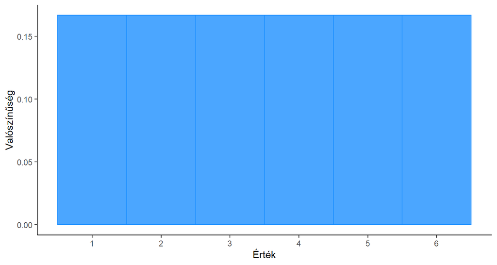

## Ábrázolás

Eloszlásfüggvény \[F(x)=P(\xi<x_i)\]

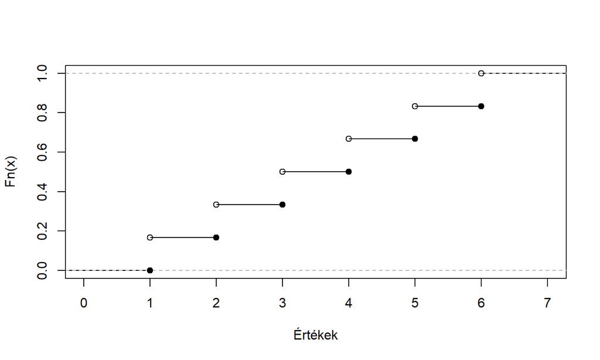

## Várható érték

## Várható érték

Ha a kísérletet ismételten elvégezzük, a kapott értékek egy meghatározott érték körül ingadoznak.

Ezt nevezzük a változó *várható értékének*  
Jelölése: \[E(\xi)\]

[Katt!](https://seeing-theory.brown.edu/basic-probability/index.html#section2)

## Kiszámítása

\[E(\xi)=\sum_{i=1}^{n}x_i*P(\xi=x_i)\]

## Kiszámítása

| x<sub>i</sub> | 1 | 2 | 3 | 4 | 5 | 6 |
| --- | --- | --- | --- | --- | --- | --- |
| P(ξ=x<sub>i</sub>) | 1/6 | 1/6 | 1/6 | 1/6 | 1/6 | 1/6 |

\(E(\xi)=1*\frac{1}{6}+\)

## Kiszámítása

| x<sub>i</sub> | 1 | 2 | 3 | 4 | 5 | 6 |
| --- | --- | --- | --- | --- | --- | --- |
| P(ξ=x<sub>i</sub>) | 1/6 | 1/6 | 1/6 | 1/6 | 1/6 | 1/6 |

\(E(\xi)=1*\frac{1}{6}+2*\frac{1}{6}+\)

## Kiszámítása

| x<sub>i</sub> | 1 | 2 | 3 | 4 | 5 | 6 |
| --- | --- | --- | --- | --- | --- | --- |
| P(ξ=x<sub>i</sub>) | 1/6 | 1/6 | 1/6 | 1/6 | 1/6 | 1/6 |

\(E(\xi)=1*\frac{1}{6}+2*\frac{1}{6}+3*\frac{1}{6}+\)

## Kiszámítása

| x<sub>i</sub> | 1 | 2 | 3 | 4 | 5 | 6 |
| --- | --- | --- | --- | --- | --- | --- |
| P(ξ=x<sub>i</sub>) | 1/6 | 1/6 | 1/6 | 1/6 | 1/6 | 1/6 |

\(E(\xi)=1*\frac{1}{6}+2*\frac{1}{6}+3*\frac{1}{6}+4*\frac{1}{6}+\)

## Kiszámítása

| x<sub>i</sub> | 1 | 2 | 3 | 4 | 5 | 6 |
| --- | --- | --- | --- | --- | --- | --- |
| P(ξ=x<sub>i</sub>) | 1/6 | 1/6 | 1/6 | 1/6 | 1/6 | 1/6 |

\(E(\xi)=1*\frac{1}{6}+2*\frac{1}{6}+3*\frac{1}{6}+4*\frac{1}{6}+5*\frac{1}{6}+\)

## Kiszámítása

| x<sub>i</sub> | 1 | 2 | 3 | 4 | 5 | 6 |
| --- | --- | --- | --- | --- | --- | --- |
| P(ξ=x<sub>i</sub>) | 1/6 | 1/6 | 1/6 | 1/6 | 1/6 | 1/6 |

\(E(\xi)=1*\frac{1}{6}+2*\frac{1}{6}+3*\frac{1}{6}+4*\frac{1}{6}+5*\frac{1}{6}+6*\frac{1}{6}\)

## Kiszámítása

| x<sub>i</sub> | 1 | 2 | 3 | 4 | 5 | 6 |
| --- | --- | --- | --- | --- | --- | --- |
| P(ξ=x<sub>i</sub>) | 1/6 | 1/6 | 1/6 | 1/6 | 1/6 | 1/6 |

\(E(\xi)=1*\frac{1}{6}+2*\frac{1}{6}+3*\frac{1}{6}+4*\frac{1}{6}+5*\frac{1}{6}+6*\frac{1}{6}=3,5\)

Ez felfogható, mint az egyes értékeknek a valószínűségekkel súlyozott átlaga.  
Vagy másképpen: ez az értékek súlypontja.

## A várható érték

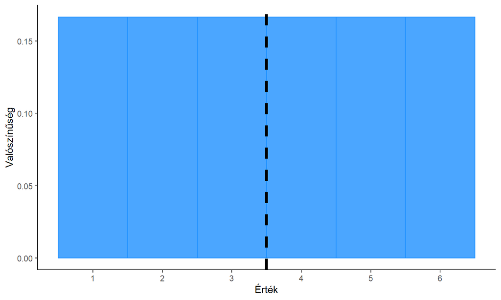

## Szórás

## Szórás

Ugyanaz a várható érték többféleképpen is kijöhet. Ezért a változók jellemzésére a várható érték mellett egy másik mutatót is használunk.

[Katt!](https://seeing-theory.brown.edu/basic-probability/index.html#section3)

A *variancia* (szórásnégyzet) a várható értéktől való eltérések négyzeteinek várható értéke (átlaga).  
A *szórás* ennek a négyzetgyöke.  
Jelölése: \[D(\xi)\]

## Kiszámítása

\[D(\xi)=\sqrt{E(\xi^2)-E^2(\xi)}\] ahol \[E(\xi^2)=\sum_{i=1}^{n}x_i^2*P(\xi=x_i)\]

## Kiszámítása

| x<sub>i</sub> | 1 | 2 | 3 | 4 | 5 | 6 |
| --- | --- | --- | --- | --- | --- | --- |
| P(ξ=x<sub>i</sub>) | 1/6 | 1/6 | 1/6 | 1/6 | 1/6 | 1/6 |

\(E(\xi^2)=1^2*\frac{1}{6}+\)

## Kiszámítása

| x<sub>i</sub> | 1 | 2 | 3 | 4 | 5 | 6 |
| --- | --- | --- | --- | --- | --- | --- |
| P(ξ=x<sub>i</sub>) | 1/6 | 1/6 | 1/6 | 1/6 | 1/6 | 1/6 |

\(E(\xi^2)=1^2*\frac{1}{6}+2^2*\frac{1}{6}+\)

## Kiszámítása

| x<sub>i</sub> | 1 | 2 | 3 | 4 | 5 | 6 |
| --- | --- | --- | --- | --- | --- | --- |
| P(ξ=x<sub>i</sub>) | 1/6 | 1/6 | 1/6 | 1/6 | 1/6 | 1/6 |

\(E(\xi^2)=1^2*\frac{1}{6}+2^2*\frac{1}{6}+3^2*\frac{1}{6}+\)

## Kiszámítása

| x<sub>i</sub> | 1 | 2 | 3 | 4 | 5 | 6 |
| --- | --- | --- | --- | --- | --- | --- |
| P(ξ=x<sub>i</sub>) | 1/6 | 1/6 | 1/6 | 1/6 | 1/6 | 1/6 |

\(E(\xi^2)=1^2*\frac{1}{6}+2^2*\frac{1}{6}+3^2*\frac{1}{6}+4^2*\frac{1}{6}+\)

## Kiszámítása

| x<sub>i</sub> | 1 | 2 | 3 | 4 | 5 | 6 |
| --- | --- | --- | --- | --- | --- | --- |
| P(ξ=x<sub>i</sub>) | 1/6 | 1/6 | 1/6 | 1/6 | 1/6 | 1/6 |

\(E(\xi^2)=1^2*\frac{1}{6}+2^2*\frac{1}{6}+3^2*\frac{1}{6}+4^2*\frac{1}{6}+5^2*\frac{1}{6}+\)

## Kiszámítása

| x<sub>i</sub> | 1 | 2 | 3 | 4 | 5 | 6 |
| --- | --- | --- | --- | --- | --- | --- |
| P(ξ=x<sub>i</sub>) | 1/6 | 1/6 | 1/6 | 1/6 | 1/6 | 1/6 |

\(E(\xi^2)=1^2*\frac{1}{6}+2^2*\frac{1}{6}+3^2*\frac{1}{6}+4^2*\frac{1}{6}+5^2*\frac{1}{6}+6^2*\frac{1}{6}\)

## Kiszámítása

| x<sub>i</sub> | 1 | 2 | 3 | 4 | 5 | 6 |
| --- | --- | --- | --- | --- | --- | --- |
| P(ξ=x<sub>i</sub>) | 1/6 | 1/6 | 1/6 | 1/6 | 1/6 | 1/6 |

\(E(\xi^2)=1^2*\frac{1}{6}+2^2*\frac{1}{6}+3^2*\frac{1}{6}+4^2*\frac{1}{6}+5^2*\frac{1}{6}+6^2*\frac{1}{6}=15\frac{1}{6}\)

## Kiszámítása

\[D(\xi)=\sqrt{E(\xi^2)-E^2(\xi)}\]

## Kiszámítása

\[D(\xi)=\sqrt{15,17-3,5^2}\approx 1,71\]

## További feladatok

1. Ketten lőnek célba…
2. Egy dobozból húzunk…